# (online food delivery platform Exploration)

## by (Sarah Oftadeh)

## Investigation Aspects

- main channel of revenue among all vendor types
- the difference of customer behaviour
- order trend during different hours in a day for the most ordered vendor type
- failure/success of ordered of the most favorite vendortype and during different times in a day as well as the relationship of expected delivery time in determining the status.
- Delivery/pickup preference in determining the fail/success of orders.

## Dataset Overview

> There is about 1m food orders for an online application, operating in 14 different cities in Malaysia, the payment was done either CoD or online, devices used to place orders were mobile, tablet and desktop. the status of orders (if the order was successful or failed). the voucher usage indicates whether they used voucher to make the purchase or not. Data for customer preferrence over delivery or pickup has also been gathered.

## Vendor Type Distribution

about 95% of customers placed orders from restaurants

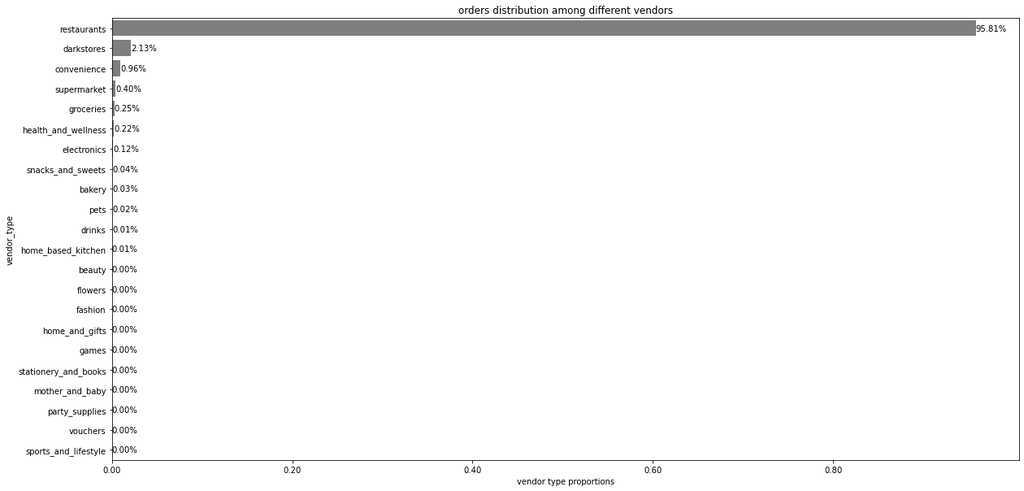

## Customer Behaviour

### Restaurants :

- 96% of orders were successful with 4% failed rate, like dark stores only 3% of orders were made by first time shoppers, mobile is the only device used for this category.
- In terms of payment onine banking, cash on delivery stands in the first place followed by online banking and online card payment.
- Most majority of users were organic with rate of 83%.
- 97% of orders where delivered by company delivery service and only 3% preferred to pickup their orders themselves.

### Darkstores:

- 99% of orders were successful, only 4% of orders were made by first time shoppers, 99% of them used their mobile phone.
- In terms of payment onine banking, cash on delivery and card payment all had close rates with Online banking being on top.
- 61% of purchases were made through organic customers who didnt use any vouchers to complete their orders.
- 100% of orders were delivered to the customers

### Shops:

- In shops 90% of orders were successful, like dark stores only 4% of orders were made by first time shoppers, mobile is the solo dominant device for its users.
- In terms of payment onine banking, like darkstores but with higher rate cash on delivery stands in the first place followed by online banking and online card payment.
- 74% of purchases were made through organic customers who didnt use any vouchers to complete their orders.
- only 2% of customers picked up their orders and the rest had them delivered.

```
customer behaviour in Restaurants:
```

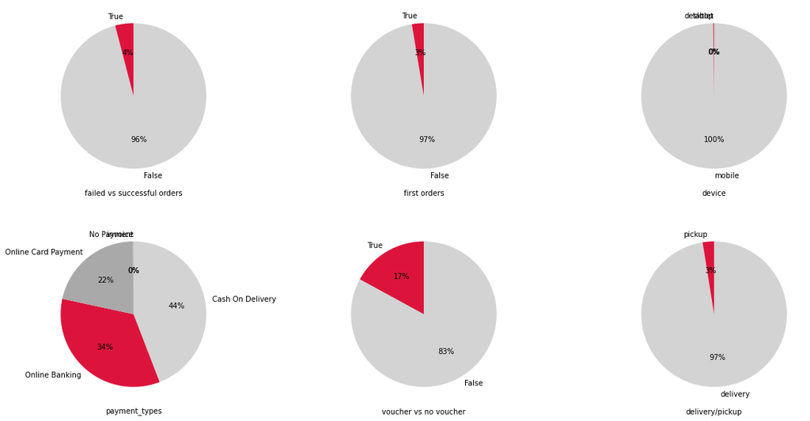

```
customer behaviour in Darkstores:
```

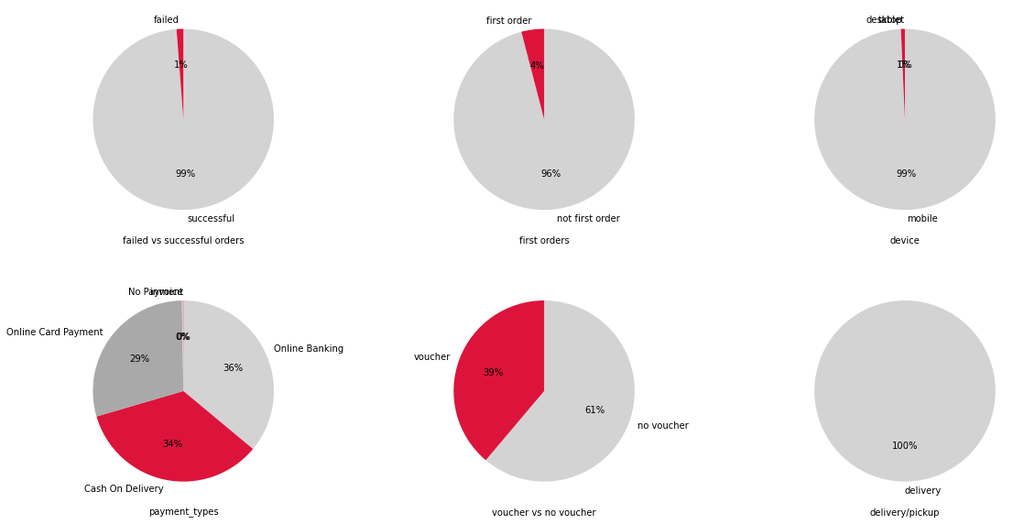

```
customer behaviour in Shops:
```

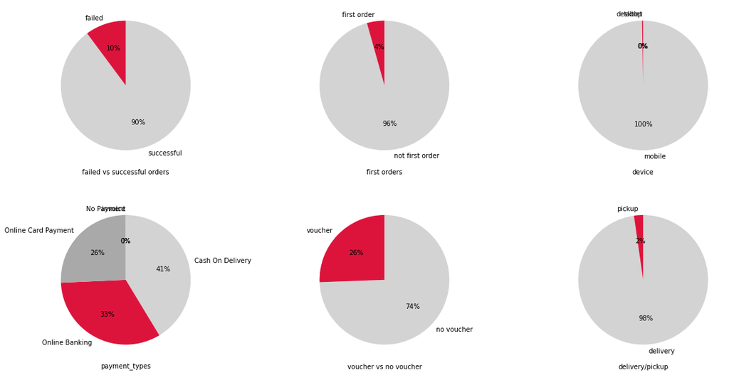